# Multiple Regression

The BigMart Inventory management exercise - SOLUTION

I. Joly

2023-11-15

```r
library(tidyverse)
```

# 1 Bigmart Sales Data Set using machine learning for bigenners

Retail industry uses analytics to optimize business processes. Tasks like product placement, inventory management, customized offers, product bundling, etc. are being smartly handled using data science techniques.

## 1.1 Variables description

- `Item_Identifier` : Unique product ID
- `Item_Fat_Content` : Whether the product is low fat or not
- `Item_Type` : The category to which the product belongs
- `Outlet_Identifier` : Unique store ID
- `Outlet_Size` : The size of the store in terms of ground area covered
- `Outlet_Location_Type` : The type of city in which the store is located
- `Outlet_Type` : Whether the outlet is just a grocery store or some sort of supermarket
- `Item_Weight` : Weight of product
- `Item_Visibility` : The % of total display area of all products in a store allocated to the particular product
- `Item_MRP` : Maximum Retail Price (list price) of the product
- `Outlet_Establishment_Year` : The year in which store was established
- `Item_Outlet_Sales`: Sales of the product in the particular store. This is the outcome variable to be predicted.

## 1.2 Problem: Predict the sales of a store

The data are collection of 8523 sales data for 1559 products across 10 stores in different cities. Also, certain attributes of each product and store have been defined. The aim is to build a predictive model and find out the sales of each product at a particular store.

Using this model, we will try to understand the properties of products and stores which play a key role in increasing sales.

## 1.3 The Hypotheses

Here we draw some hypotheses on the potential determinants of the products demand.

*Store Level Hypotheses:*

- **City type**: Stores located in `urban` or `Tier 1` cities should have higher sales because of the higher income levels of people there.
- **Population Density**: Stores demand should be positively associated with population density.
- **Store Capacity**: Stores capacity should act as an attracting factor and rises demand.
- **Competitors**: Stores competitive environment should have negative effect on sales.
- **Marketing**: Stores which have a good marketing division should have higher sales as it will be able to attract customers through the right offers and advertising.
- **Location**: Stores located within popular marketplaces should have higher sales because of better access to customers.
- **Customer Behavior**: Stores keeping the right set of products to meet the local needs of customers will have higher sales.
- **Ambiance**: Stores which are well-maintained and managed by polite and humble people are expected to have higher footfall and thus higher sales.

*Product Level Hypotheses:*

- **Brand**: Branded products should have higher trust and then sales.
- **Age of the product**: Time on the market should help positive reputation and image building.
- **Packaging**: Good packaging can attract customers.
- **Utility**: Higher quality products should have higher utility and sale.
- **Display Area**: Products on bigger shelves in the store should sell more.
- **Visibility in Store**: The location of product in a store will impact sales.
- **Advertising**: Better advertising of products in the store will should higher sales in most cases.
- **Promotional Offers**: Products accompanied with attractive offers and discounts will sell more.

## 1.4 Data exploration

### 1.4.2 Second we reduce item type (`Item_Type`) to 3 categories only: *Food, Drinks and Non-Consumables*

The `Item_Type` variable has 16 categories which might prove to be very useful in analysis. So its a good idea to combine them. One way could be to assign a new category to each. `Item_Identifier`, i.e. the unique ID of each item, it starts with either `FD`, `DR` or `NC`. It like being Food, Drinks and Non-Consumables.

### 1.4.3 Third we correct some typos in `Item_Fat_Content`

There are typos and difference in representation in categories of `Item_Fat_Content` variable.

There were some non-consumables as well and a fat-content should not be specified for them.

```r
# Item_FAt_Content
DF %>% select(Item_Fat_Content) %>% table
```

```
## Item_Fat_Content
##      LF low fat Low Fat     reg Regular
##     316     112    5089     117    2889
```

```r
DF <-  dplyr::mutate(DF,
              Item_Fat_Content = case_when(Item_Fat_Content %in% c("LF","low fat","Low Fat") ~ "Low Fat",
                                           Item_Fat_Content %in% c("reg","Regular") ~ "Regular"))
DF$Item_Fat_Content <- factor(DF$Item_Fat_Content)
table(DF$Item_Fat_Content)
```

```
##
## Low Fat Regular
##    5517    3006
```

```r
# Item_Type
table(DF$Item_Identifier)
```

[output not shown]

```r
DF <- DF %>% mutate(DF,
              Item_Type2 = case_when( str_detect(Item_Identifier, "DR") ~ "Drink",
                                       str_detect(Item_Identifier, "FD") ~ "Food",
                                       str_detect(Item_Identifier, "NC") ~ "Non Consommable"))
DF <- DF %>% separate(Item_Identifier, c("Item_Type2", "Item_Id"), sep = 2)
table(DF$Item_Type, DF$Item_Type2 )
```

```
##
##                           DR   FD   NC
##   Baking Goods             0  648    0
##   Breads                   0  251    0
##   Breakfast                0  110    0
##   Canned                   0  649    0
##   Dairy                  140  542    0
##   Frozen Foods             0  856    0
##   Fruits and Vegetables    0 1232    0
##   Hard Drinks            214    0    0
##   Health and Hygiene       0    0  520
##   Household                0    0  910
##   Meat                     0  425    0
##   Others                   0    0  169
##   Seafood                  0   64    0
##   Snack Foods              0 1200    0
##   Soft Drinks            445    0    0
##   Starchy Foods            0  148    0
```

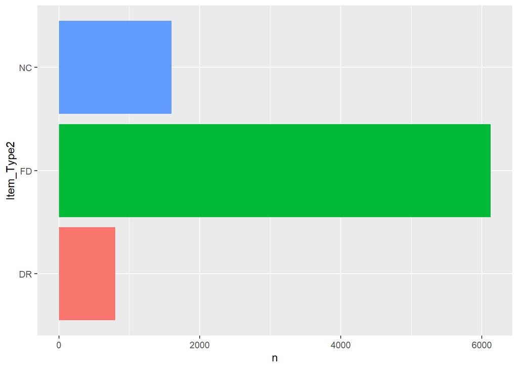

[figure not shown]

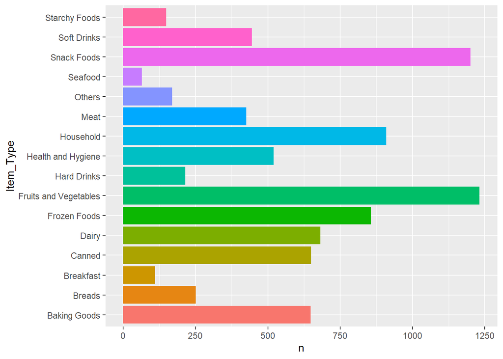

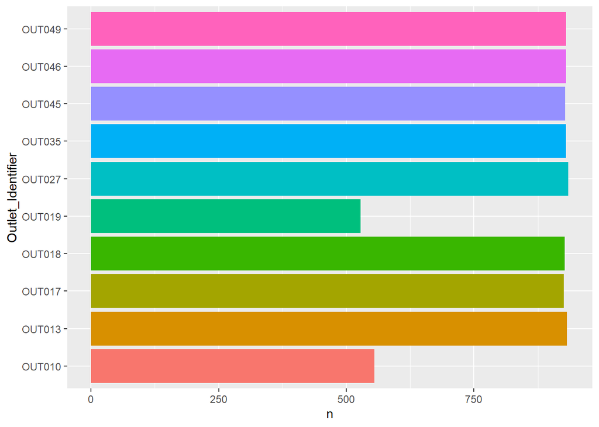

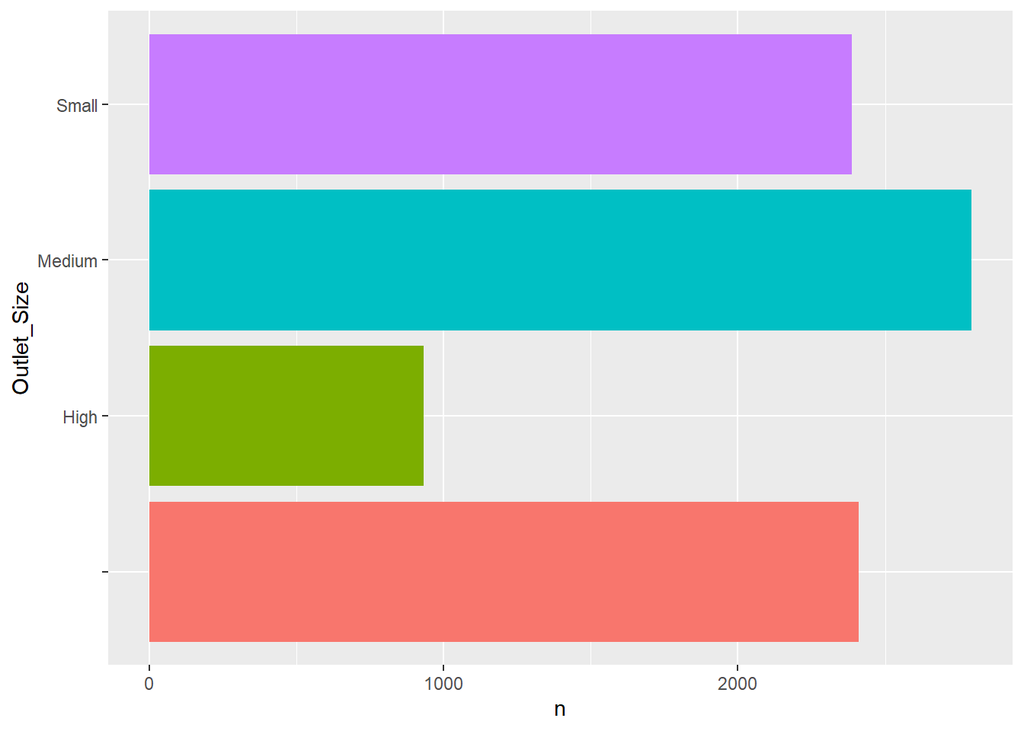

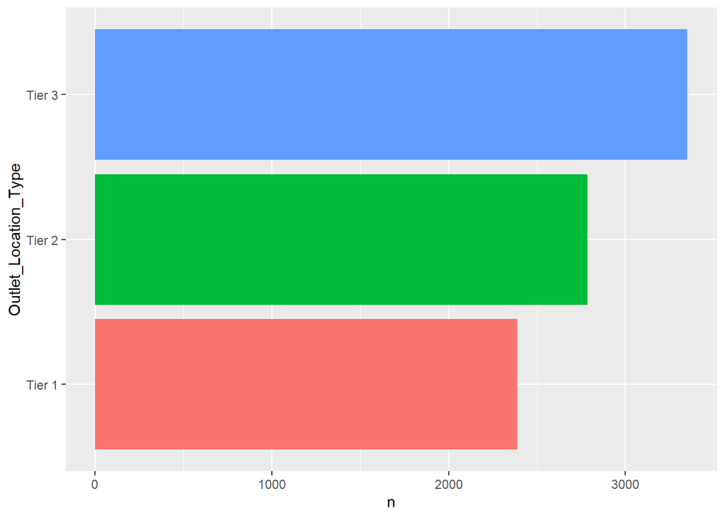

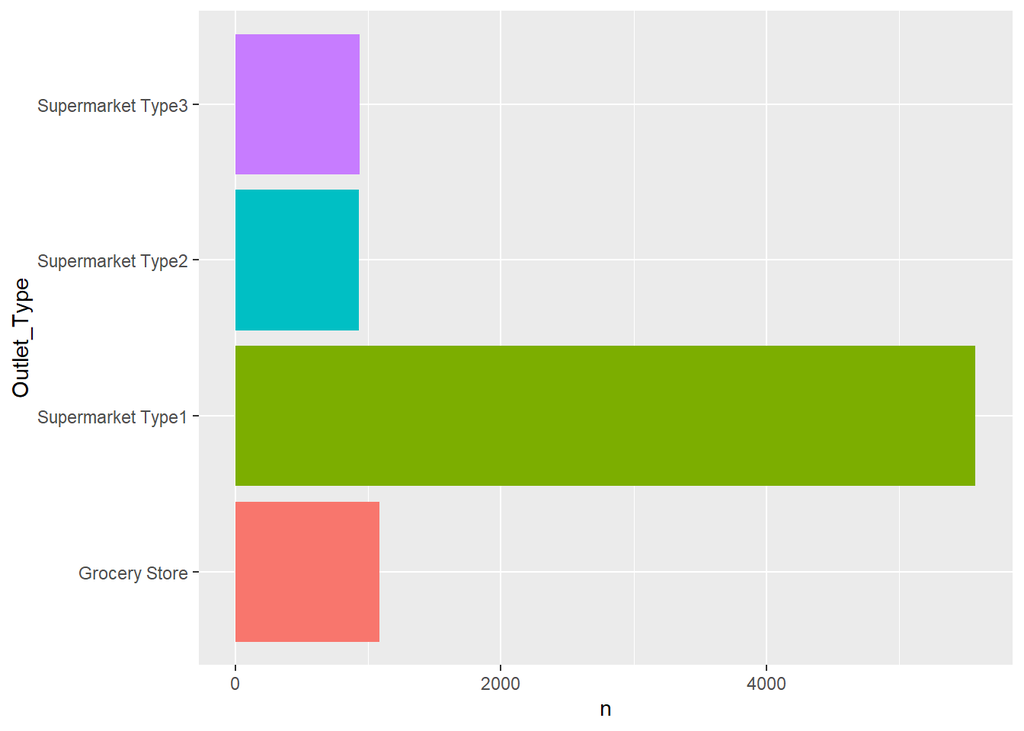

```r
## Counting the freq for each character var

var_freq_plot_fn <- function(df){
  purrr::map(df %>% select_if(is.character) %>% names, ~
  df %>%
    count(.data[[.x]]) %>%
    ggplot(aes(x = n, y = .data[[.x]], fill = .data[[.x]])) +
    geom_col() +
    theme(legend.position = "none"))
}

var_freq_plot_fn(DF)
```

```r
## Counting NA for each var

NA_count_fn <- function(df){
  df %>% select(everything()) %>%  # replace to your needs
  summarise_all(funs(sum(is.na(.)) / length(.)))
}
NA_count_fn(DF)
```

```
##   Item_Type2 Item_Id Item_Weight Item_Fat_Content Item_Visibility Item_Type
## 1          0       0   0.1716532                0               0         0
##   Item_MRP Outlet_Identifier Outlet_Establishment_Year Outlet_Size
## 1        0                 0                         0           0
##   Outlet_Location_Type Outlet_Type Item_Outlet_Sales
## 1                    0           0                 0
```

```r
# Average imputation for Missing `Item_Weight`
DF <- DF %>%
  group_by(Item_Type2) %>%
  mutate(Av_weight = mean(Item_Weight, na.rm=T)) %>%
  ungroup() %>%
  mutate(Item_Weight2 = ifelse(is.na(Item_Weight),  Av_weight, Item_Weight))

sum(is.na(DF$Item_Weight2))
```

```
## [1] 0
```

# 2 Data Formating

## 2.1 Categorical data

```r
DF$Item_Type2 <- factor(DF$Item_Type2)
DF$Item_Fat_Content <- factor(DF$Item_Fat_Content)
DF$Outlet_Establishment_Year <- factor(DF$Outlet_Establishment_Year)
DF$Outlet_Size <- factor(DF$Outlet_Size)
DF$Outlet_Location_Type <- factor(DF$Outlet_Location_Type)
DF$Outlet_Type <- factor(DF$Outlet_Type)
```

# 3 Regression analysis

## 3.1 Simple regression

Let start with simple regression model. First we evaluate one variable impact on the sales. Justify your choice of explanatory variable and perform and discuss the regression.

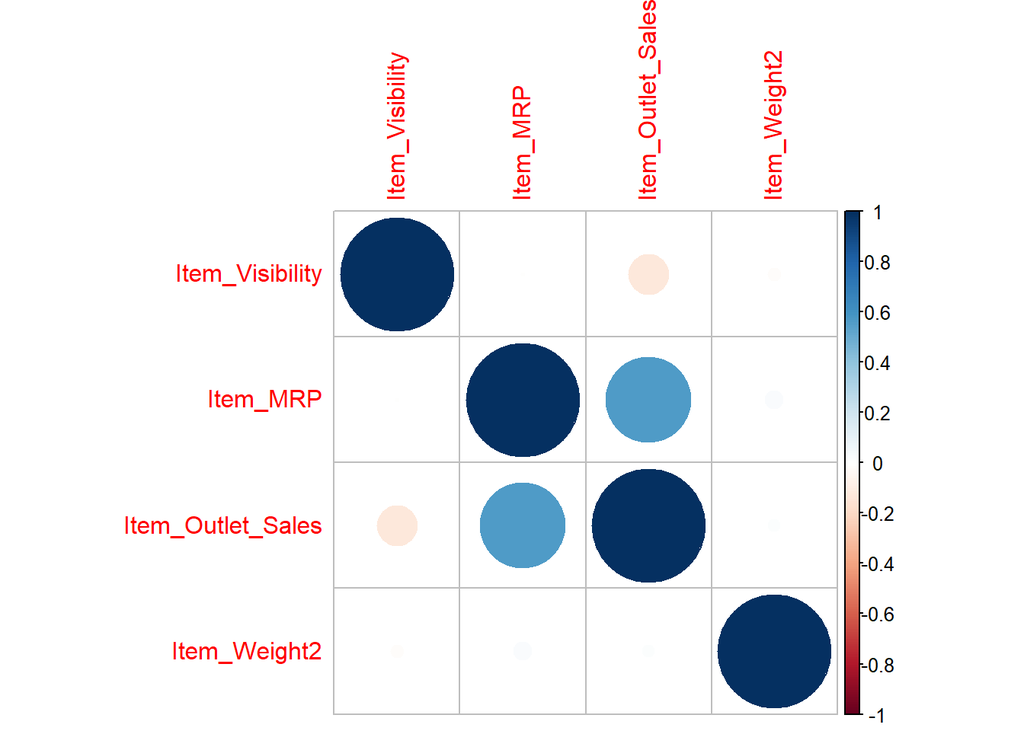

```r
my.cor <- DF  %>% select_if(is.numeric) %>% select( -Item_Weight, -Av_weight) %>% cor
corrplot::corrplot(my.cor)
```

```r
Reg1 <- lm(data=DF, Item_Outlet_Sales ~ Item_MRP)
summary(Reg1)
```

```
##
## Call:
## lm(formula = Item_Outlet_Sales ~ Item_MRP, data = DF)
##
## Residuals:
##     Min      1Q  Median      3Q     Max
## -3871.2  -770.1   -64.0   696.4  9443.6
##
## Coefficients:
##             Estimate Std. Error t value Pr(>|t|)
## (Intercept) -11.5751    37.6712  -0.307    0.759
## Item_MRP     15.5530     0.2444  63.635   <2e-16 ***
## ---
## Signif. codes:  0 '***' 0.001 '**' 0.01 '*' 0.05 '.' 0.1 ' ' 1
##
## Residual standard error: 1405 on 8521 degrees of freedom
## Multiple R-squared:  0.3221, Adjusted R-squared:  0.3221
## F-statistic:  4049 on 1 and 8521 DF,  p-value: < 2.2e-16
```

This regression shows significant correlation between sales and price (as expected). We can use these results as benchmark to evaluate the following regressions

### 3.1.1 Regression diagnostic

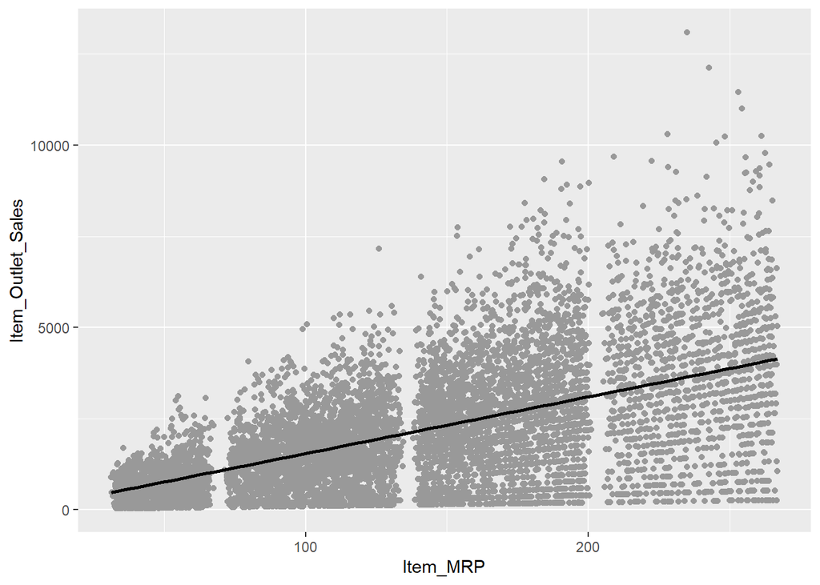

```r
sp <- ggplot(DF, aes(x=Item_MRP, y=Item_Outlet_Sales)) +
  geom_point(colour="grey60") +
  stat_smooth(method=lm,  colour="black")
sp
```

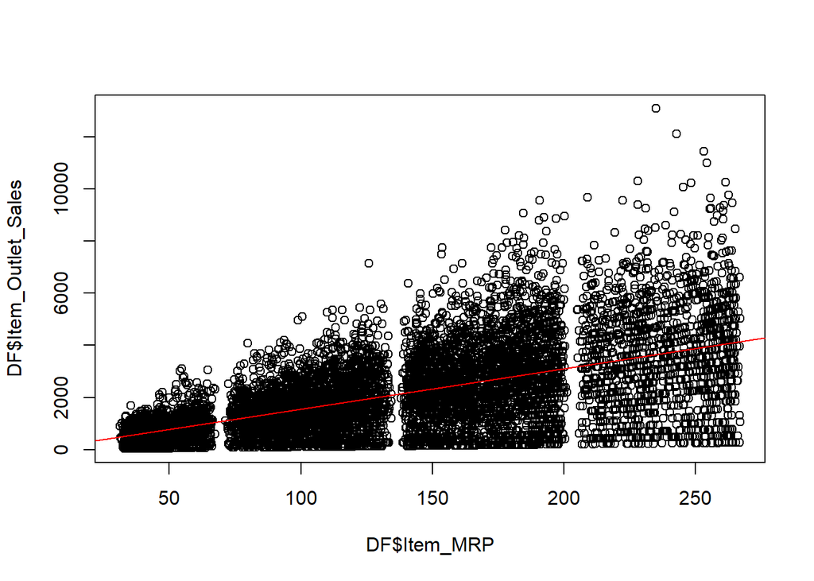

```r
plot(DF$Item_Outlet_Sales ~ DF$Item_MRP)
abline(Reg1, col='red')
```

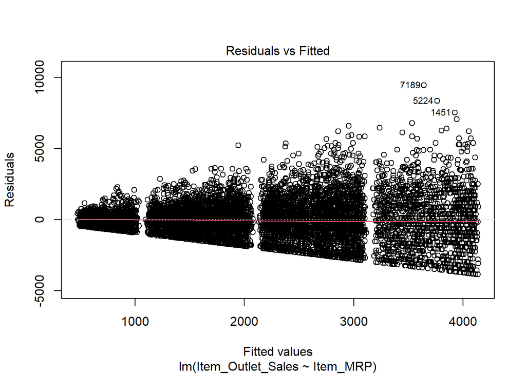

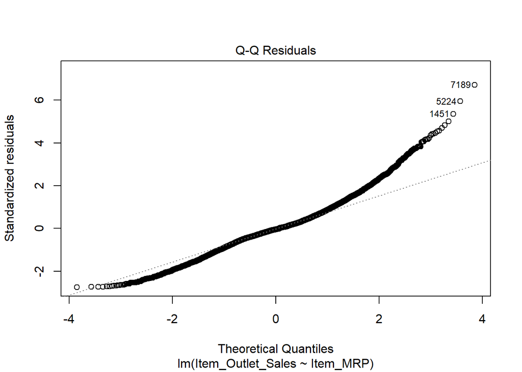

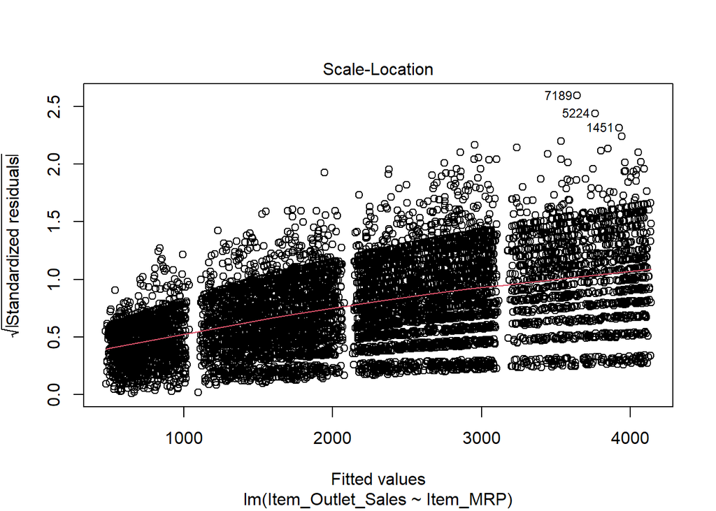

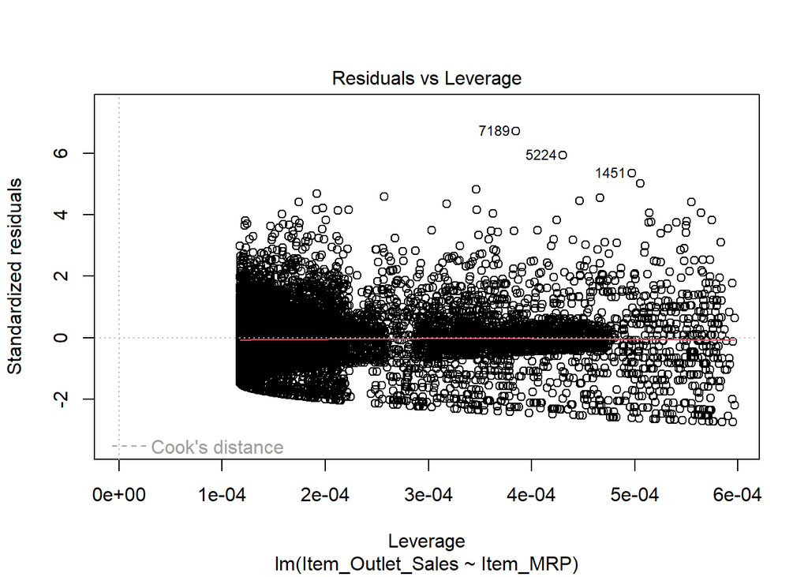

```r
plot(Reg1)
```

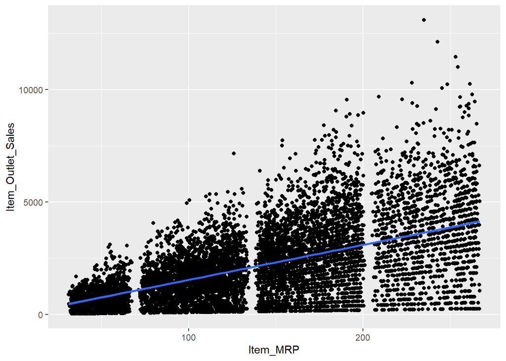

```r
ggplot(DF,aes(Item_MRP, Item_Outlet_Sales)) +
  geom_point() +
  geom_smooth(method='lm'
              #, se=FALSE
              )
```

## 3.2 Multiple regression

### 3.2.1 Regression with quantitative variables:

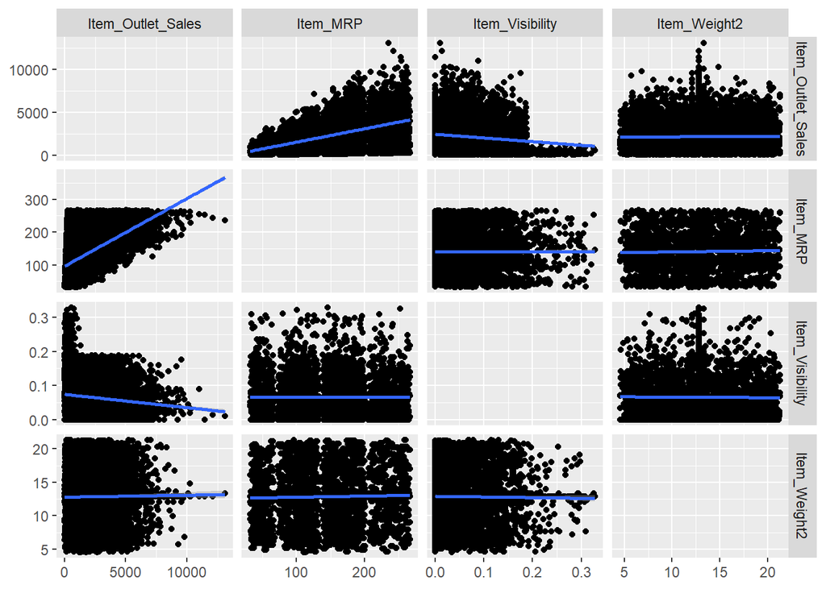

```r
library(ggforce)

ggplot(DF, aes(x = .panel_x, y = .panel_y)) +
  geom_point() +
  geom_smooth(method = "lm") +
  ggforce::facet_matrix(vars(Item_Outlet_Sales , Item_MRP , Item_Visibility ,  Item_Weight2), layer.diag = 4)
```

```r
Reg2 <- lm(data=DF, Item_Outlet_Sales ~ Item_MRP + Item_Visibility +  Item_Weight2)
summary(Reg2)
```

```
##
## Call:
## lm(formula = Item_Outlet_Sales ~ Item_MRP + Item_Visibility +
##     Item_Weight2, data = DF)
##
## Residuals:
##     Min      1Q  Median      3Q     Max
## -4102.1  -791.7   -79.2   682.3  9209.5
##
## Coefficients:
##                   Estimate Std. Error t value Pr(>|t|)
## (Intercept)       289.9093    61.6029   4.706 2.56e-06 ***
## Item_MRP           15.5513     0.2415  64.383  < 2e-16 ***
## Item_Visibility -4231.0196   291.4575 -14.517  < 2e-16 ***
## Item_Weight2       -1.6667     3.5579  -0.468    0.639
## ---
## Signif. codes:  0 '***' 0.001 '**' 0.01 '*' 0.05 '.' 0.1 ' ' 1
##
## Residual standard error: 1388 on 8519 degrees of freedom
## Multiple R-squared:  0.3385, Adjusted R-squared:  0.3383
## F-statistic:  1453 on 3 and 8519 DF,  p-value: < 2.2e-16
```

### 3.2.2 Searching for Outlet impact on sales

Let discuss the regression of sales on establishment year, size and type of outlet. Comment regression results.

```r
Reg3 <- lm(data=DF, Item_Outlet_Sales ~ Outlet_Establishment_Year + Outlet_Size + Outlet_Type)
summary(Reg3)
```

```
##
## Call:
## lm(formula = Item_Outlet_Sales ~ Outlet_Establishment_Year +
##     Outlet_Size + Outlet_Type, data = DF)
##
## Residuals:
##     Min      1Q  Median      3Q     Max
## -3452.4 -1063.1  -186.5   673.8  9392.9
##
## Coefficients: (5 not defined because of singularities)
##                                 Estimate Std. Error t value Pr(>|t|)
## (Intercept)                     340.3297    64.7419   5.257  1.5e-07 ***
## Outlet_Establishment_Year1987  1958.6655    81.0315  24.172  < 2e-16 ***
## Outlet_Establishment_Year1997  1937.5145    81.0630  23.901  < 2e-16 ***
## Outlet_Establishment_Year1998    -0.9781    90.4384  -0.011    0.991
## Outlet_Establishment_Year1999 -1345.6839    68.8961 -19.532  < 2e-16 ***
## Outlet_Establishment_Year2002  1852.0551    81.0788  22.843  < 2e-16 ***
## Outlet_Establishment_Year2004  2098.5121    81.0630  25.887  < 2e-16 ***
## Outlet_Establishment_Year2007  2000.3455    81.1264  24.657  < 2e-16 ***
## Outlet_Establishment_Year2009 -1698.5398    68.9333 -24.640  < 2e-16 ***
## Outlet_SizeHigh                       NA         NA      NA       NA
## Outlet_SizeMedium              3353.7088    80.9845  41.412  < 2e-16 ***
## Outlet_SizeSmall                      NA         NA      NA       NA
## Outlet_TypeSupermarket Type1          NA         NA      NA       NA
## Outlet_TypeSupermarket Type2          NA         NA      NA       NA
## Outlet_TypeSupermarket Type3          NA         NA      NA       NA
## ---
## Signif. codes:  0 '***' 0.001 '**' 0.01 '*' 0.05 '.' 0.1 ' ' 1
##
## Residual standard error: 1488 on 8513 degrees of freedom
## Multiple R-squared:  0.2408, Adjusted R-squared:   0.24
## F-statistic: 300.1 on 9 and 8513 DF,  p-value: < 2.2e-16
```

```r
table(DF$Outlet_Size, DF$Outlet_Type)
```

```
##
##          Grocery Store Supermarket Type1 Supermarket Type2 Supermarket Type3
##                    555              1855                 0                 0
##   High               0               932                 0                 0
##   Medium             0               930               928               935
##   Small            528              1860                 0                 0
```

### 3.2.3 Mixing with Item variables

```r
Reg4 <- lm(data=DF, Item_Outlet_Sales ~ Item_Fat_Content + Item_Type2)
summary(Reg4)
```

```
##
## Call:
## lm(formula = Item_Outlet_Sales ~ Item_Fat_Content + Item_Type2,
##     data = DF)
##
## Residuals:
##     Min      1Q  Median      3Q     Max
## -2195.5 -1345.0  -390.3   917.1 10944.2
##
## Coefficients:
##                         Estimate Std. Error t value Pr(>|t|)
## (Intercept)              1994.93      60.46  32.998  < 2e-16 ***
## Item_Fat_ContentRegular    27.09      42.73   0.634  0.52615
## Item_Type2FD              207.45      66.28   3.130  0.00176 **
## Item_Type2NC              147.79      73.99   1.998  0.04579 *
## ---
## Signif. codes:  0 '***' 0.001 '**' 0.01 '*' 0.05 '.' 0.1 ' ' 1
##
## Residual standard error: 1706 on 8519 degrees of freedom
## Multiple R-squared:  0.001519,   Adjusted R-squared:  0.001167
## F-statistic:  4.32 on 3 and 8519 DF,  p-value: 0.004747
```

```r
Reg4 <- lm(data=DF, Item_Outlet_Sales ~ Item_MRP * Item_Type2)
summary(Reg4)
```

```
##
## Call:
## lm(formula = Item_Outlet_Sales ~ Item_MRP * Item_Type2, data = DF)
##
## Residuals:
##     Min      1Q  Median      3Q     Max
## -3931.3  -766.7   -58.5   705.0  9610.0
##
## Coefficients:
##                       Estimate Std. Error t value Pr(>|t|)
## (Intercept)             0.5326   115.3687   0.005    0.996
## Item_MRP               15.2455     0.7949  19.178   <2e-16 ***
## Item_Type2FD          -45.7346   123.7312  -0.370    0.712
## Item_Type2NC          118.4742   145.1074   0.816    0.414
## Item_MRP:Item_Type2FD   0.6588     0.8456   0.779    0.436
## Item_MRP:Item_Type2NC  -0.9560     0.9781  -0.977    0.328
## ---
## Signif. codes:  0 '***' 0.001 '**' 0.01 '*' 0.05 '.' 0.1 ' ' 1
##
## Residual standard error: 1405 on 8517 degrees of freedom
## Multiple R-squared:  0.3229, Adjusted R-squared:  0.3225
## F-statistic: 812.3 on 5 and 8517 DF,  p-value: < 2.2e-16
```

## 3.3 Prediction

Using the first regression model : `Reg1`: `Item_Outlet_Sales ~ Item_MRP` we can predict sales for new data: new values of `Item_MRP`

```r
Reg1 <- lm(data=DF, Item_Outlet_Sales ~ Item_MRP)
summary(Reg1)
```

```
##
## Call:
## lm(formula = Item_Outlet_Sales ~ Item_MRP, data = DF)
##
## Residuals:
##     Min      1Q  Median      3Q     Max
## -3871.2  -770.1   -64.0   696.4  9443.6
##
## Coefficients:
##             Estimate Std. Error t value Pr(>|t|)
## (Intercept) -11.5751    37.6712  -0.307    0.759
## Item_MRP     15.5530     0.2444  63.635   <2e-16 ***
## ---
## Signif. codes:  0 '***' 0.001 '**' 0.01 '*' 0.05 '.' 0.1 ' ' 1
##
## Residual standard error: 1405 on 8521 degrees of freedom
## Multiple R-squared:  0.3221, Adjusted R-squared:  0.3221
## F-statistic:  4049 on 1 and 8521 DF,  p-value: < 2.2e-16
```

```r
new.data <- data.frame(Item_MRP = c(mean(DF$Item_MRP), median(DF$Item_MRP)))
#predict(Reg1 , new.data)
new.data2 <- data.frame( Item_MRP =   seq(min((DF$Item_MRP), max(DF$Item_MRP))))
predict(Reg1,  new.data2 ,interval = "prediction")
```

```
##           fit       lwr      upr
## 1    3.977881 -2751.300 2759.256
## 2   19.530904 -2735.735 2774.797
## 3   35.083928 -2720.171 2790.339
## 4   50.636951 -2704.606 2805.880
## 5   66.189975 -2689.042 2821.422
## 6   81.742998 -2673.478 2836.964
## 7   97.296022 -2657.913 2852.505
## 8  112.849045 -2642.349 2868.047
## 9  128.402069 -2626.785 2883.589
## 10 143.955093 -2611.221 2899.131
## 11 159.508116 -2595.657 2914.674
## 12 175.061140 -2580.094 2930.216
## 13 190.614163 -2564.530 2945.758
## 14 206.167187 -2548.966 2961.301
## 15 221.720210 -2533.403 2976.843
## 16 237.273234 -2517.839 2992.386
## 17 252.826257 -2502.276 3007.928
## 18 268.379281 -2486.712 3023.471
## 19 283.932304 -2471.149 3039.014
## 20 299.485328 -2455.586 3054.557
## 21 315.038351 -2440.023 3070.100
## 22 330.591375 -2424.460 3085.643
## 23 346.144398 -2408.897 3101.186
## 24 361.697422 -2393.334 3116.729
## 25 377.250446 -2377.772 3132.272
##  [ getOption("max.print") est atteint -- 6 lignes omises ]
```

```r
newDF <- data.frame(Item_MRP = DF$Item_MRP)
pred1 <- as.data.frame(predict(Reg1,  newDF, interval = "prediction"))
names(pred1) <- c( "Item_Outlet_Sales", "lower", "upper")
```

```r
# example that can be modified
predict(lm(y ~ x), new, se.fit = TRUE)
pred.w.plim <- predict(lm(y ~ x), new, interval = "prediction")
pred.w.clim <- predict(lm(y ~ x), new, interval = "confidence")
matplot(new$x, cbind(pred.w.clim, pred.w.plim[,-1]),
        lty = c(1,2,2,3,3), type = "l", ylab = "predicted y")
```

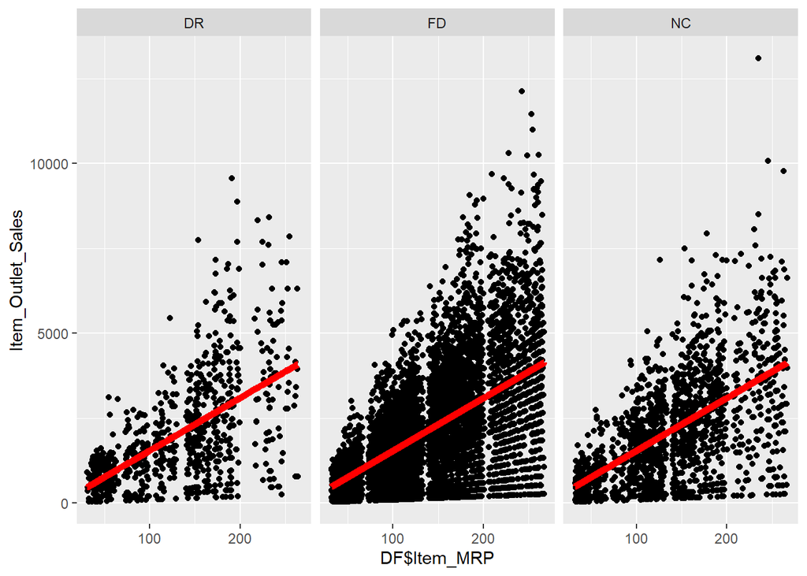

```r
ggplot(DF, aes(DF$Item_MRP, Item_Outlet_Sales)) +
geom_point()+
  facet_wrap(~ DF$Item_Type2)+ geom_line(data = pred1, lwd =2 , colour='red')
```